# vtreat scale mode

Win-Vector LLC

2016-04-19

`vtreat::prepare(scale=TRUE)` is a variation of `vtreat::prepare()` intended to prepare data frames so all the derived x variables (input or independent variables) are fully in y (outcome or dependent variable) units (in the sense of a regression, categorical/logical y’s are treated as 0/1 indicators) and mean-zero.

This is the appropriate preparation before a geometry/metric sensitive modeling step such as principal components analysis or clustering (such as k-means clustering).

Normally (with `vtreat::prepare(scale=FALSE)`) vtreat passes through a number of variables with minimal alteration (cleaned numerics), builds 0/1 indicator variables for various conditions (categorical levels, presence of NAs, and so on), and builds some “in y-units” variables (catN, catB) that are in fact sub-models. With `vtreat::prepare(scale=TRUE)` all of these numeric variables are then re-processed to have mean zero, and slope 1 (when possible) when numerically regressed against the y-variable.

This is easiest to illustrate with a concrete example.

```r
library('vtreat')
dTrainC <- data.frame(x=c('a','a','a','b','b',NA),
                      z=c(1,2,3,4,NA,6),
                      y=c(FALSE,FALSE,TRUE,FALSE,TRUE,TRUE))
treatmentsC <- designTreatmentsC(dTrainC,colnames(dTrainC),'y',TRUE,
                                 verbose=FALSE)
dTrainCTreatedUnscaled <- prepare(treatmentsC,dTrainC,pruneSig=c(),scale=FALSE)
dTrainCTreatedScaled <- prepare(treatmentsC,dTrainC,pruneSig=c(),scale=TRUE)
```

The standard vtreat treated frame converts the original data from this:

```r
print(dTrainC)
```

```
##      x  z     y
## 1    a  1 FALSE
## 2    a  2 FALSE
## 3    a  3  TRUE
## 4    b  4 FALSE
## 5    b NA  TRUE
## 6 <NA>  6  TRUE
```

into this:

```r
print(dTrainCTreatedUnscaled)
```

```
##   x_lev_NA x_lev_x.a x_lev_x.b    x_catP     x_catB z_clean z_isBAD     y
## 1        0         1         0 0.5000000 -0.4052985     1.0       0 FALSE
## 2        0         1         0 0.5000000 -0.4052985     2.0       0 FALSE
## 3        0         1         0 0.5000000 -0.4052985     3.0       0  TRUE
## 4        0         0         1 0.3333333  0.0000000     4.0       0 FALSE
## 5        0         0         1 0.3333333  0.0000000     3.2       1  TRUE
## 6        1         0         0 0.1666667  0.6926476     6.0       0  TRUE
```

This is the “standard way” to run vtreat (with the exception of having set `pruneSig` to `NULL` instead of a value in the interval `(0,1)`). The idea is: even though vtreat try to have vtreat do as perform as little as possible alteration on the data (which in fact turns out to already be a lot of alteration) leaving as much as possible to the downstream machine learning code. Mostly vtreat is taking only steps that are unsafe to leave for later (re-encoding of large categoricals, re-coding of aberrant values, and bulk pruning of variables).

However some procedures (in particular principal components analysis or geometric clustering) assume all of the columns have been transformed in a similar fashion.  
The usual assumption (“more honored in the breach than the observance”) is the columns are centered (mean zero) and scaled. Now the non y-aware meaning if “scaled” is unit variance. However, vtreat is designed to emphasize y-aware processing and we feel the y-aware sense of scaling should be: unit slope when regressed against y. If you want standard scaling you can use the standard frame produce by vtreat and scale it yourself. If you want vtreat style y-aware scaling you (which we strongly think is the right thing to do) you can use `vtreat::prepare(scale=TRUE)` which produces a frame that looks like the following:

```r
print(dTrainCTreatedScaled)
```

```
##   x_lev_NA  x_lev_x.a x_lev_x.b x_catP      x_catB     z_clean z_isBAD
## 1     -0.1 -0.1666667         0   -0.2 -0.18838870 -0.38648649    -0.1
## 2     -0.1 -0.1666667         0   -0.2 -0.18838870 -0.21081081    -0.1
## 3     -0.1 -0.1666667         0   -0.2 -0.18838870 -0.03513514    -0.1
## 4     -0.1  0.1666667         0    0.1  0.05164882  0.14054054    -0.1
## 5     -0.1  0.1666667         0    0.1  0.05164882  0.00000000     0.5
## 6      0.5  0.1666667         0    0.4  0.46186845  0.49189189    -0.1
##       y
## 1 FALSE
## 2 FALSE
## 3  TRUE
## 4 FALSE
## 5  TRUE
## 6  TRUE
```

First we can check the claims. Are the variables mean-zero and slope 1 when regressed against y?

```r
slopeFrame <- data.frame(varName = treatmentsC$scoreFrame$varName,
                         stringsAsFactors = FALSE)
slopeFrame$mean <-
  vapply(dTrainCTreatedScaled[, slopeFrame$varName, drop = FALSE], mean,
         numeric(1))
slopeFrame$slope <- vapply(slopeFrame$varName,
                           function(c) {
                             lm(paste('y', c, sep = '~'),
                                data = dTrainCTreatedScaled)$coefficients[[2]]
                           },
                           numeric(1))
slopeFrame$sig <- vapply(slopeFrame$varName,
                         function(c) {
                           treatmentsC$scoreFrame[treatmentsC$scoreFrame$varName == c, 'sig']
                         },
                         numeric(1))
slopeFrame$badSlope <-
  ifelse(is.na(slopeFrame$slope), TRUE, abs(slopeFrame$slope - 1) > 1.e-8)
print(slopeFrame)
```

```
##     varName          mean slope        sig badSlope
## 1  x_lev_NA  6.938894e-18     1 0.20766228    FALSE
## 2 x_lev_x.a  0.000000e+00     1 0.40972582    FALSE
## 3 x_lev_x.b  0.000000e+00    NA 1.00000000     TRUE
## 4    x_catP -7.401487e-17     1 0.25493078    FALSE
## 5    x_catB  2.312965e-18     1 0.05044486    FALSE
## 6   z_clean  2.775558e-17     1 0.14299775    FALSE
## 7   z_isBAD  6.938894e-18     1 0.20766228    FALSE
```

This is true with the exception of the derived variable `x_lev_x.b`. The issue is that the outcome variable `y` has identical distribution when the original variable `x==‘b’` and when `x!=‘b’` (on half the time in both cases). This means `y` is perfectly independent of `x==‘b’` and the regression slope must be zero. vtreat now treats this as needing to scale by a multiplicative factor of zero, which if you look up set the value of `x_lev_x.b` to identically zero in the scaled frame. This is subtle, but it is what is safest for downstream analysis. We don’t want useless (or nearly useless) variables taking on infinitesimal values that might be inverted into ridiculously large coefficients.

Note also the “varMoves” and significance facts in `treatmentsC$scoreFrame` are about the unscaled frame (where `x_lev_x.b` does in fact move). However the only exceptional cases in scaling are variables that don’t achieve any modeling significance, so filtering on `treatmentsC\(scoreFrame\)sig` eliminates any exceptional cases (and prevents the needless passing of effective constants to downstream modeling).

Previous versions of vtreat (0.5.22 and earlier) would to copy (unaltered) variables that could not be sensibly scaled. This was considered the “most faithful” thing to do. However we feel unscalable variables are more usefully and safely (to downstream procedures) represented as a column of zeros (especially for the package authors intended/anticipated applications of scaled frames: principal components analysis and geometric clustering). This is essentially what vtreat now does. This does preclude using such variables in interactions or trees (where they may actually have value), so an analyst wishing to preserve such variables must either not scale or introduce the interaction before variable treatment.

Principal components analysis example.

```r
# build example where even and odd variables are bringing in noisy images
# of two different signals.
set.seed(23525)
n <- 500
yA <- rnorm(n)
yB <- rnorm(n)
d <- data.frame(y=yA+yB+rnorm(n))
yS <- list(yA,yB)
for(i in 1:5) {
  vi <- yS[[1+(i%%2)]] + rnorm(nrow(d))
  d[[paste('x',i,sep='.')]] <- (1+i)*vi
}
for(i in 1:45) {
  vi <- (1+i)*(rnorm(n))
  d[[paste('noise',i,sep='.')]] <- (1+i)*vi
}
summary(d)
```

```
##        y                 x.1               x.2
##  Min.   :-5.24540   Min.   :-7.3322   Min.   :-11.0403
##  1st Qu.:-0.98646   1st Qu.:-1.6050   1st Qu.: -2.5196
##  Median : 0.06855   Median : 0.2440   Median :  0.2180
##  Mean   : 0.16497   Mean   : 0.1603   Mean   :  0.2205
##  3rd Qu.: 1.17759   3rd Qu.: 1.9254   3rd Qu.:  3.2275
##  Max.   : 4.53140   Max.   : 7.9740   Max.   : 13.1649
##       x.3                x.4                x.5
##  Min.   :-18.0522   Min.   :-20.7776   Min.   :-22.3619
##  1st Qu.: -3.5300   1st Qu.: -4.6907   1st Qu.: -5.1310
##  Median :  0.4983   Median :  0.2533   Median :  0.6043
##  Mean   :  0.1441   Mean   :  0.1757   Mean   :  0.5095
##  3rd Qu.:  3.6709   3rd Qu.:  5.0503   3rd Qu.:  6.2839
##  Max.   : 17.4943   Max.   : 19.8530   Max.   : 25.7125
##     noise.1             noise.2            noise.3
##  Min.   :-10.63380   Min.   :-24.4543   Min.   :-53.5950
##  1st Qu.: -2.78887   1st Qu.: -5.5808   1st Qu.:-11.0995
##  Median : -0.02016   Median :  0.6825   Median :  0.3491
##  Mean   : -0.06190   Mean   :  0.3138   Mean   : -0.2842
##  3rd Qu.:  2.70795   3rd Qu.:  6.0157   3rd Qu.: 10.2475
##  Max.   : 12.28095   Max.   : 27.4266   Max.   : 51.7527
##     noise.4            noise.5             noise.6
##  Min.   :-64.3262   Min.   :-106.2136   Min.   :-169.891
##  1st Qu.:-16.2533   1st Qu.: -25.1943   1st Qu.: -27.423
##  Median : -0.1482   Median :  -2.2011   Median :   3.719
##  Mean   :  0.2626   Mean   :  -0.6195   Mean   :   2.780
##  3rd Qu.: 15.9967   3rd Qu.:  23.4275   3rd Qu.:  33.829
##  Max.   : 81.5608   Max.   : 116.6358   Max.   : 153.293
##     noise.7            noise.8            noise.9
##  Min.   :-183.297   Min.   :-269.083   Min.   :-263.596
##  1st Qu.: -38.152   1st Qu.: -59.294   1st Qu.: -76.961
##  Median :   1.361   Median :   5.575   Median :  -4.595
##  Mean   :   1.078   Mean   :   1.905   Mean   :  -2.680
##  3rd Qu.:  45.846   3rd Qu.:  57.593   3rd Qu.:  71.290
##  Max.   : 173.490   Max.   : 239.561   Max.   : 278.920
##     noise.10           noise.11           noise.12
##  Min.   :-324.564   Min.   :-419.985   Min.   :-587.891
##  1st Qu.: -69.851   1st Qu.: -73.590   1st Qu.:-118.542
##  Median :   4.733   Median :  14.261   Median :   3.019
##  Mean   :   6.187   Mean   :   7.641   Mean   :   1.070
```

[output cut: 64 more lines]

```
##  Max.   : 4980.87   Max.   : 6862.69   Max.   : 6551.14
##     noise.41           noise.42            noise.43
##  Min.   :-4891.21   Min.   :-5984.350   Min.   :-5516.69
##  1st Qu.:-1283.94   1st Qu.:-1349.490   1st Qu.:-1288.61
##  Median :  -80.39   Median :   16.480   Median :  117.82
##  Mean   :  -40.06   Mean   :   -0.619   Mean   :   46.34
##  3rd Qu.: 1320.20   3rd Qu.: 1334.047   3rd Qu.: 1301.45
##  Max.   : 4947.79   Max.   : 5627.458   Max.   : 5859.89
##     noise.44            noise.45
##  Min.   :-5921.721   Min.   :-7888.17
##  1st Qu.:-1483.194   1st Qu.:-1572.23
##  Median :  -56.976   Median :   21.55
##  Mean   :    5.602   Mean   :   12.72
##  3rd Qu.: 1291.616   3rd Qu.: 1474.44
##  Max.   : 6589.306   Max.   : 6580.45
```

```r
# transform and principal y-away principal components analysis.
treatmentsN <- designTreatmentsN(d,setdiff(colnames(d),'y'),'y',
                                 verbose=FALSE)
print(treatmentsN$scoreFrame[,c('varName','origName','code','sig')])
```

```
##           varName origName  code          sig
## 1       x.1_clean      x.1 clean 3.969362e-18
## 2       x.2_clean      x.2 clean 1.458168e-23
## 3       x.3_clean      x.3 clean 5.362524e-18
## 4       x.4_clean      x.4 clean 2.854575e-24
## 5       x.5_clean      x.5 clean 8.551528e-27
## 6   noise.1_clean  noise.1 clean 1.000000e+00
## 7   noise.2_clean  noise.2 clean 1.000000e+00
## 8   noise.3_clean  noise.3 clean 1.000000e+00
## 9   noise.4_clean  noise.4 clean 1.000000e+00
## 10  noise.5_clean  noise.5 clean 1.000000e+00
## 11  noise.6_clean  noise.6 clean 1.000000e+00
## 12  noise.7_clean  noise.7 clean 1.000000e+00
## 13  noise.8_clean  noise.8 clean 1.000000e+00
## 14  noise.9_clean  noise.9 clean 1.000000e+00
```

[output cut: 36 more lines]

```r
examplePruneSig = 1.0 # note set pruneSig < 1 for any real world application
# we are setting it to 1.0 to deliberately lose the benefit of variable prune
# to illustrate that you recover some of benefit of variable pruning due
# to the scaling effect (which in this case gives noise variable small range
# meaning they don't have much of an effect in the principal components anlaysis).
# This example is designed so we "know the right answer" (which is why it obvious
# what to prune).
dTrainNTreatedScaled <- prepare(treatmentsN,d,pruneSig=examplePruneSig,scale=TRUE)
# notice the signal carrying variables have commensurate ranges and the noise
# variables have very small ranges.
summary(dTrainNTreatedScaled)
```

```
##    x.1_clean          x.2_clean            x.3_clean
##  Min.   :-1.73185   Min.   :-1.9351704   Min.   :-2.04367
##  1st Qu.:-0.40806   1st Qu.:-0.4708881   1st Qu.:-0.41265
##  Median : 0.01935   Median :-0.0004262   Median : 0.03978
##  Mean   : 0.00000   Mean   : 0.0000000   Mean   : 0.00000
##  3rd Qu.: 0.40797   3rd Qu.: 0.5167431   3rd Qu.: 0.39611
##  Max.   : 1.80606   Max.   : 2.2244811   Max.   : 1.94864
##    x.4_clean          x.5_clean         noise.1_clean
##  Min.   :-2.17912   Min.   :-2.001686   Min.   :-0.1558015
##  1st Qu.:-0.50611   1st Qu.:-0.493650   1st Qu.:-0.0349633
##  Median : 0.00807   Median : 0.008295   Median :-0.0005269
##  Mean   : 0.00000   Mean   : 0.000000   Mean   : 0.0000000
##  3rd Qu.: 0.50694   3rd Qu.: 0.505369   3rd Qu.: 0.0344220
##  Max.   : 2.04641   Max.   : 2.205740   Max.   : 0.1334471
##  noise.2_clean       noise.3_clean        noise.4_clean
##  Min.   :-0.196041   Min.   :-0.0221887   Min.   :-0.0386659
##  1st Qu.:-0.046656   1st Qu.:-0.0045015   1st Qu.:-0.0098872
##  Median : 0.002918   Median : 0.0002636   Median :-0.0002459
##  Mean   : 0.000000   Mean   : 0.0000000   Mean   : 0.0000000
##  3rd Qu.: 0.045131   3rd Qu.: 0.0043834   3rd Qu.: 0.0094192
##  Max.   : 0.214600   Max.   : 0.0216584   Max.   : 0.0486689
##  noise.5_clean        noise.6_clean        noise.7_clean
##  Min.   :-0.0230140   Min.   :-0.1084414   Min.   :-0.2914379
##  1st Qu.:-0.0047198   1st Qu.:-0.0223703   1st Qu.:-0.0756754
##  Median : 0.0003104   Median :-0.0006768   Median :-0.0004787
##  Mean   : 0.0000000   Mean   : 0.0000000   Mean   : 0.0000000
##  3rd Qu.: 0.0048234   3rd Qu.: 0.0217608   3rd Qu.: 0.0663119
##  Max.   : 0.0207253   Max.   : 0.1244052   Max.   : 0.3116580
##  noise.8_clean       noise.9_clean        noise.10_clean
##  Min.   :-0.146581   Min.   :-0.1421955   Min.   :-0.0164744
##  1st Qu.:-0.034347   1st Qu.:-0.0373515   1st Qu.:-0.0034991
##  Median :-0.002264   Median : 0.0009671   Median : 0.0000674
##  Mean   : 0.000000   Mean   : 0.0000000   Mean   : 0.0000000
##  3rd Qu.: 0.037747   3rd Qu.: 0.0375088   3rd Qu.: 0.0035259
##  Max.   : 0.167140   Max.   : 0.1317516   Max.   : 0.0153369
##  noise.11_clean      noise.12_clean       noise.13_clean
##  Min.   :-0.173454   Min.   :-0.0358506   Min.   :-5.103e-02
##  1st Qu.:-0.032949   1st Qu.:-0.0072809   1st Qu.:-1.107e-02
##  Median : 0.002685   Median : 0.0001187   Median : 6.453e-05
##  Mean   : 0.000000   Mean   : 0.0000000   Mean   : 0.000e+00
```

[output cut: 64 more lines]

```
##  Max.   : 0.448926   Max.   : 2.574e-02   Max.   : 0.201320
##  noise.41_clean      noise.42_clean      noise.43_clean
##  Min.   :-0.148503   Min.   :-0.382447   Min.   :-0.258705
##  1st Qu.:-0.038077   1st Qu.:-0.086212   1st Qu.:-0.062081
##  Median :-0.001235   Median : 0.001093   Median : 0.003324
##  Mean   : 0.000000   Mean   : 0.000000   Mean   : 0.000000
##  3rd Qu.: 0.041640   3rd Qu.: 0.085305   3rd Qu.: 0.058368
##  Max.   : 0.152688   Max.   : 0.359715   Max.   : 0.270355
##  noise.44_clean      noise.45_clean             y
##  Min.   :-0.195227   Min.   :-0.2947444   Min.   :-5.24540
##  1st Qu.:-0.038134   1st Qu.:-0.0591270   1st Qu.:-0.98646
##  Median : 0.001856   Median : 0.0003296   Median : 0.06855
##  Mean   : 0.000000   Mean   : 0.0000000   Mean   : 0.16497
##  3rd Qu.: 0.044147   3rd Qu.: 0.0545299   3rd Qu.: 1.17759
##  Max.   : 0.175763   Max.   : 0.2450110   Max.   : 4.53140
```

```r
vars <- setdiff(colnames(dTrainNTreatedScaled),'y')
# prcomp defaults to scale. = FALSE, but we already scaled in vtreat- so that is okay
princ <- prcomp(as.matrix(dTrainNTreatedScaled[,vars]))
print(princ$sdev)
```

```
##  [1] 0.992597547 0.928286669 0.480064497 0.477402221 0.466190970
##  [6] 0.198780724 0.153321407 0.128106764 0.119889112 0.105956806
## [11] 0.101751207 0.087281123 0.080685736 0.077078847 0.076532532
## [16] 0.074827988 0.072283413 0.070920642 0.067197273 0.066621534
## [21] 0.066245869 0.064200230 0.062714059 0.061106006 0.058624258
## [26] 0.053808996 0.052922682 0.051464358 0.050710179 0.049669233
## [31] 0.047746306 0.047208929 0.045306873 0.043218629 0.041977999
## [36] 0.040270317 0.035159820 0.033029051 0.029771408 0.028363197
## [41] 0.025560686 0.020465586 0.014847253 0.014024482 0.013487950
## [46] 0.010495726 0.006854124 0.006283495 0.005984575 0.004968988
```

```r
# pull off the rotation.
# we don't use scaling terms as we don't want any duplicated variables to be
# counted twice.  we are trying to preserve the novelty of the original geometry
# not all of the original distances.
ndim <- 2
rot <- princ$rotation[,1:ndim]
# sign was arbitrary, so flip in convenient form
for(i in seq_len(ndim)) {
  si <- sign(mean(rot[,i]))
  if(si!=0) {
    rot[,i] <- rot[,i]*si
  }
}
# notice even/odd loadings are recovered
print(rot)
```

```
##                          PC1           PC2
## x.1_clean       4.944492e-01  9.994809e-02
## x.2_clean      -7.217316e-02  6.923643e-01
## x.3_clean       5.021073e-01  4.818736e-02
## x.4_clean      -7.428101e-02  7.111373e-01
## x.5_clean       7.015853e-01  4.140585e-02
## noise.1_clean   1.756819e-03 -1.830484e-03
## noise.2_clean  -2.055877e-03  3.303291e-03
## noise.3_clean   4.743089e-04 -4.360576e-04
## noise.4_clean   2.473890e-04  5.064225e-04
## noise.5_clean  -2.806638e-04 -1.929395e-04
## noise.6_clean  -1.994877e-03  1.228769e-03
## noise.7_clean  -2.666689e-03  2.914978e-03
## noise.8_clean   1.757318e-03 -1.168735e-03
## noise.9_clean   3.056399e-03 -7.364978e-06
## noise.10_clean  3.174061e-04  2.816192e-04
## noise.11_clean  3.367341e-03 -2.981889e-03
## noise.12_clean  1.750139e-04  4.479107e-04
## noise.13_clean  6.808148e-04  1.751074e-04
## noise.14_clean  9.489388e-04  1.354278e-03
## noise.15_clean  1.795632e-03 -8.306136e-05
## noise.16_clean  2.825504e-03 -1.658786e-03
## noise.17_clean  2.788948e-03 -2.801602e-03
## noise.18_clean  2.130758e-03 -1.556162e-03
## noise.19_clean -3.207671e-04 -1.090064e-03
## noise.20_clean  2.400294e-03  1.360489e-03
## noise.21_clean -1.568185e-03  2.348391e-03
## noise.22_clean  1.146346e-02  1.590494e-02
## noise.23_clean -9.443726e-04  1.526618e-03
## noise.24_clean  1.059495e-03 -1.218793e-03
## noise.25_clean  4.231817e-03 -7.668693e-04
## noise.26_clean -1.742942e-03  1.369068e-02
## noise.27_clean -2.358467e-03  2.118312e-03
## noise.28_clean  1.431646e-03 -2.240777e-04
## noise.29_clean  1.796004e-03  1.147272e-03
## noise.30_clean  3.620898e-03  2.560024e-03
## noise.31_clean  3.098092e-03 -7.393108e-04
## noise.32_clean -2.406988e-04  1.401657e-03
## noise.33_clean  8.444606e-03  2.727033e-03
## noise.34_clean  1.407991e-03 -1.154869e-03
## noise.35_clean  5.316866e-04 -6.754367e-04
## noise.36_clean -1.510161e-04  9.797127e-04
## noise.37_clean -1.943657e-03  1.449789e-03
## noise.38_clean  1.948748e-03  1.592735e-02
## noise.39_clean -3.306018e-05  7.364548e-05
## noise.40_clean  1.228211e-03  1.873838e-04
## noise.41_clean  2.133185e-03 -1.228807e-03
## noise.42_clean -1.116643e-03  9.321208e-03
## noise.43_clean  9.123639e-03 -2.851027e-03
## noise.44_clean -2.363745e-03  6.316645e-04
## noise.45_clean  4.295676e-03  2.805900e-03
```

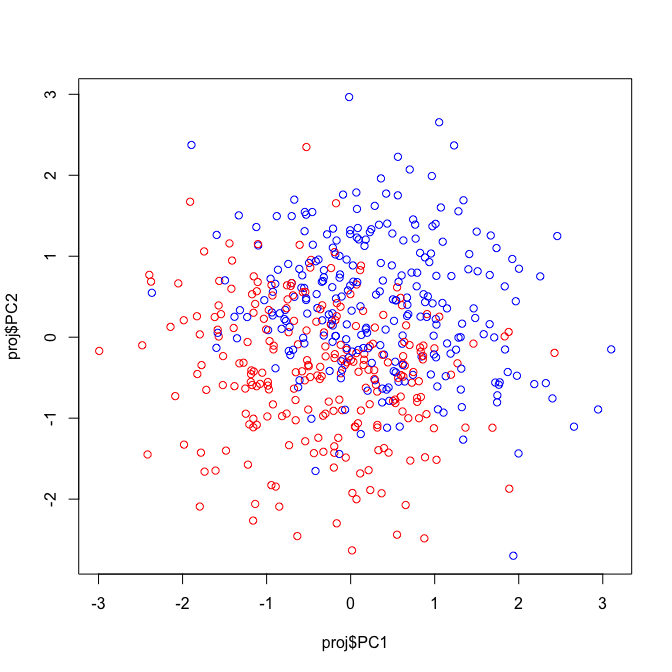

```r
# apply projection
proj <- as.data.frame(as.matrix(dTrainNTreatedScaled[,vars]) %*% rot,
                      stringsAsFactors = FALSE)

# plot data sorted by principal components
# notice we y increases both as we move up and as we move right.
# we recoved two features correlating with y increase (not just smeared together to one)
proj$y <- dTrainNTreatedScaled$y
#library('ggplot2')
#ggplot(data=proj,aes(x=PC1,y=PC2,color=y>0)) + geom_point(size=2,alpha=0.5)
plot(proj$PC1,proj$PC2,col=ifelse(proj$y>=0,'blue','red'))
```

Show how, without y-aware scaling principal components can not preserved the y-relations (as it not designed to).

```r
dTrainNTreatedUnscaled <- prepare(treatmentsN,d,pruneSig=examplePruneSig,scale=FALSE)
summary(dTrainNTreatedUnscaled)
```

```
##    x.1_clean         x.2_clean          x.3_clean
##  Min.   :-7.3322   Min.   :-11.0403   Min.   :-18.0522
##  1st Qu.:-1.6050   1st Qu.: -2.5196   1st Qu.: -3.5300
##  Median : 0.2440   Median :  0.2180   Median :  0.4983
##  Mean   : 0.1603   Mean   :  0.2205   Mean   :  0.1441
##  3rd Qu.: 1.9254   3rd Qu.:  3.2275   3rd Qu.:  3.6709
##  Max.   : 7.9740   Max.   : 13.1649   Max.   : 17.4943
##    x.4_clean          x.5_clean        noise.1_clean
##  Min.   :-20.7776   Min.   :-22.3619   Min.   :-10.63380
##  1st Qu.: -4.6907   1st Qu.: -5.1310   1st Qu.: -2.78887
##  Median :  0.2533   Median :  0.6043   Median : -0.02016
##  Mean   :  0.1757   Mean   :  0.5095   Mean   : -0.06190
##  3rd Qu.:  5.0503   3rd Qu.:  6.2839   3rd Qu.:  2.70795
##  Max.   : 19.8530   Max.   : 25.7125   Max.   : 12.28095
##  noise.2_clean      noise.3_clean      noise.4_clean
##  Min.   :-24.4543   Min.   :-53.5950   Min.   :-64.3262
##  1st Qu.: -5.5808   1st Qu.:-11.0995   1st Qu.:-16.2533
##  Median :  0.6825   Median :  0.3491   Median : -0.1482
##  Mean   :  0.3138   Mean   : -0.2842   Mean   :  0.2626
##  3rd Qu.:  6.0157   3rd Qu.: 10.2475   3rd Qu.: 15.9967
##  Max.   : 27.4266   Max.   : 51.7527   Max.   : 81.5608
##  noise.5_clean       noise.6_clean      noise.7_clean
##  Min.   :-106.2136   Min.   :-169.891   Min.   :-183.297
##  1st Qu.: -25.1943   1st Qu.: -27.423   1st Qu.: -38.152
##  Median :  -2.2011   Median :   3.719   Median :   1.361
##  Mean   :  -0.6195   Mean   :   2.780   Mean   :   1.078
##  3rd Qu.:  23.4275   3rd Qu.:  33.829   3rd Qu.:  45.846
##  Max.   : 116.6358   Max.   : 153.293   Max.   : 173.490
##  noise.8_clean      noise.9_clean      noise.10_clean
##  Min.   :-269.083   Min.   :-263.596   Min.   :-324.564
##  1st Qu.: -59.294   1st Qu.: -76.961   1st Qu.: -69.851
##  Median :   5.575   Median :  -4.595   Median :   4.733
##  Mean   :   1.905   Mean   :  -2.680   Mean   :   6.187
##  3rd Qu.:  57.593   3rd Qu.:  71.290   3rd Qu.:  81.647
##  Max.   : 239.561   Max.   : 278.920   Max.   : 361.468
##  noise.11_clean     noise.12_clean     noise.13_clean
##  Min.   :-419.985   Min.   :-587.891   Min.   :-656.207
##  1st Qu.: -73.590   1st Qu.:-118.542   1st Qu.:-137.625
##  Median :  14.261   Median :   3.019   Median :   6.890
##  Mean   :   7.641   Mean   :   1.070   Mean   :   6.053
```

[output cut: 64 more lines]

```
##  Max.   : 4980.87   Max.   : 6862.69   Max.   : 6551.14
##  noise.41_clean     noise.42_clean      noise.43_clean
##  Min.   :-4891.21   Min.   :-5984.350   Min.   :-5516.69
##  1st Qu.:-1283.94   1st Qu.:-1349.490   1st Qu.:-1288.61
##  Median :  -80.39   Median :   16.480   Median :  117.82
##  Mean   :  -40.06   Mean   :   -0.619   Mean   :   46.34
##  3rd Qu.: 1320.20   3rd Qu.: 1334.047   3rd Qu.: 1301.45
##  Max.   : 4947.79   Max.   : 5627.458   Max.   : 5859.89
##  noise.44_clean      noise.45_clean           y
##  Min.   :-5921.721   Min.   :-7888.17   Min.   :-5.24540
##  1st Qu.:-1483.194   1st Qu.:-1572.23   1st Qu.:-0.98646
##  Median :  -56.976   Median :   21.55   Median : 0.06855
##  Mean   :    5.602   Mean   :   12.72   Mean   : 0.16497
##  3rd Qu.: 1291.616   3rd Qu.: 1474.44   3rd Qu.: 1.17759
##  Max.   : 6589.306   Max.   : 6580.45   Max.   : 4.53140
```

```r
vars <- setdiff(colnames(dTrainNTreatedUnscaled),'y')
# let prcomp try to scale (it doesn't have access to y, so it scales differently)
princ <- prcomp(as.matrix(dTrainNTreatedUnscaled[,vars]),scale. = TRUE)
print(princ$sdev)
```

```
##  [1] 1.4719804 1.3587836 1.2771455 1.2385208 1.2320008 1.2094784 1.1891934
##  [8] 1.1689051 1.1628571 1.1451379 1.1333617 1.1228350 1.1160525 1.1053061
## [15] 1.0961197 1.0870219 1.0683350 1.0531793 1.0511489 1.0398685 1.0280992
## [22] 1.0194696 1.0054393 0.9986539 0.9899682 0.9867679 0.9738572 0.9566788
## [29] 0.9491161 0.9336402 0.9279174 0.9235731 0.9097458 0.9000770 0.8872582
## [36] 0.8669252 0.8578654 0.8323551 0.8202562 0.8098249 0.8078009 0.7912694
## [43] 0.7746342 0.7590969 0.7482273 0.7381228 0.7315384 0.6500191 0.6042625
## [50] 0.5830914
```

```r
ndim <- 2
rot <- princ$rotation[,1:ndim]
# sign was arbitrary, so flip in convenient form
for(i in seq_len(ndim)) {
  si <- sign(mean(rot[,i]))
  if(si!=0) {
    rot[,i] <- rot[,i]*si
  }
}

# signal variables individuall still load better, but not as well
# sperated from noise varaibles, which eventually overwhelm the projection.
print(rot)
```

```
##                          PC1           PC2
## x.1_clean       0.5153682747  1.482730e-01
## x.2_clean      -0.0803003615  5.433237e-01
## x.3_clean       0.5398453155  4.403763e-02
## x.4_clean      -0.0759106062  5.262104e-01
## x.5_clean       0.5586291989  7.669031e-02
## noise.1_clean  -0.0226904824  2.486730e-02
## noise.2_clean  -0.0318778668  1.135104e-01
## noise.3_clean   0.0848722207  5.165061e-04
## noise.4_clean   0.0040025969  5.063014e-02
## noise.5_clean   0.0332842010  1.170368e-01
## noise.6_clean   0.0649593918 -1.044410e-01
## noise.7_clean   0.0325200139 -5.342102e-02
## noise.8_clean  -0.0649034713  6.993966e-02
## noise.9_clean  -0.0727595221 -6.215522e-03
## noise.10_clean -0.0325955874 -1.878857e-01
## noise.11_clean  0.0830399850 -1.274477e-01
## noise.12_clean  0.0208537951  6.574958e-02
## noise.13_clean  0.0403293142  6.809988e-02
## noise.14_clean  0.0201955940  1.636364e-02
## noise.15_clean -0.0927114951  1.825231e-02
## noise.16_clean -0.0354988476  7.572831e-03
## noise.17_clean -0.0523145029  7.115309e-02
## noise.18_clean -0.0778768865  5.105669e-02
## noise.19_clean -0.0153520359  1.489435e-01
## noise.20_clean  0.0310760808  7.305353e-02
## noise.21_clean  0.0310262852 -9.168881e-02
## noise.22_clean -0.0597980390 -1.490356e-01
## noise.23_clean -0.0414714056  1.165962e-01
## noise.24_clean -0.0362363102 -3.435476e-02
## noise.25_clean -0.0476008520  3.090203e-02
## noise.26_clean  0.0344958147 -2.742689e-01
## noise.27_clean -0.0595729934  1.199582e-01
## noise.28_clean  0.0409243907  5.429163e-02
## noise.29_clean -0.0466103424 -1.556602e-02
## noise.30_clean -0.0075233301 -1.209941e-01
## noise.31_clean -0.1034490186  3.589911e-02
## noise.32_clean  0.0268843597 -1.722998e-01
## noise.33_clean -0.0861222487 -2.461076e-05
## noise.34_clean -0.0053819256  6.922579e-02
## noise.35_clean  0.0092270555  4.770482e-02
## noise.36_clean  0.0008773217 -5.229810e-02
## noise.37_clean -0.0350439473 -1.513303e-02
## noise.38_clean -0.0268795328 -7.859507e-02
## noise.39_clean  0.0069411879 -6.157550e-02
## noise.40_clean  0.0298961015 -5.855721e-02
## noise.41_clean  0.0201195458  2.120363e-02
## noise.42_clean -0.0233679336  1.895269e-01
## noise.43_clean  0.1290244422 -8.276318e-02
## noise.44_clean  0.0574389994 -1.338983e-02
## noise.45_clean  0.0503112924 -4.112026e-02
```

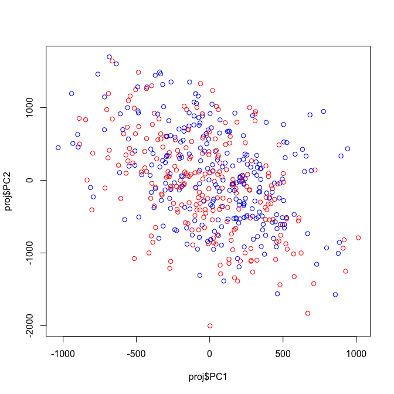

```r
# apply projection
proj <- as.data.frame(as.matrix(dTrainNTreatedUnscaled[,vars]) %*% rot,
                      stringsAsFactors = FALSE)

# plot data sorted by principal components
proj$y <- dTrainNTreatedUnscaled$y
#library('ggplot2')
#ggplot(data=proj,aes(x=PC1,y=PC2,color=y>0)) + geom_point(size=2,alpha=0.5)
plot(proj$PC1,proj$PC2,col=ifelse(proj$y>=0,'blue','red'))
```